# R Basics

Yang Yang

Brief intro of RStudio, an integrated development environment (IDE)

Anything following a # is a comment

```r
# This is a comment, which is not executed.
# You can take notes this way, e.g.Commom dataset structure:each variable is a column, each observation is a row, and each type of observational unit is a table.
```

## R as a calculator

#### Basic Math

```r
1 + 1
```

```
## [1] 2
```

```r
4 / 2 * 3
```

```
## [1] 6
```

#### R follows the order of operations PEMDAS Parenthesis Exponents Multiplication Division Addition Subtraction

```r
4 / (2*3)
```

```
## [1] 0.6667
```

#### R has built in math functions

```r
sqrt(4)
```

```
## [1] 2
```

## Assign a variable

```r
a <- 1
b <- 2   ## you can also try b=2, which is another way of assigning a variable, but arrow is generally preferred
c <- a + b
```

```r
c
```

```
## [1] 3
```

#### R is case sensitive

```r
A <- 10
```

```r
A
```

```
## [1] 10
```

```r
a    ##remember, R is case sensitive!
```

```
## [1] 1
```

#### Remove objects

```r
ls()  # R stores both data and data analysis output as objects. ls() returns a list of all objects in the current session
```

```
## [1] "a" "A" "b" "c"
```

```r
rm(a)
```

## Vectors

#### Create vectors *Note: R is case sensitive*

```r
A <- c(1,2,3,4,5)  ##Overwrite an object by assigning it something new
A
```

```
## [1] 1 2 3 4 5
```

```r
B <- 1:5; B #Commands are separated either by a ; or by a newline
```

```
## [1] 1 2 3 4 5
```

```r
C <- c(100, 40:30); C
```

```
##  [1] 100  40  39  38  37  36  35  34  33  32  31  30
```

#### Logical (hints for vector operations)

[More about operators](http://www.statmethods.net/management/operators.html)

```r
A < 2
```

```
## [1]  TRUE FALSE FALSE FALSE FALSE
```

```r
##check length
length(A); length(B)
```

```
## [1] 5
```

```
## [1] 5
```

```r
A == B
```

```
## [1] TRUE TRUE TRUE TRUE TRUE
```

```r
A != 5
```

```
## [1]  TRUE  TRUE  TRUE  TRUE FALSE
```

#### Vector Operations

```r
# add 1 to every element
A + 1
```

```
## [1] 2 3 4 5 6
```

```r
# multiplty 2 to every element
A * 2
```

```
## [1]  2  4  6  8 10
```

```r
# raise every element to second power
A ^ 2
```

```
## [1]  1  4  9 16 25
```

#### More about Vector Operations (for vectors have the same length)

```r
# +, -, *, /
A+B
```

```
## [1]  2  4  6  8 10
```

```r
A/B
```

```
## [1] 1 1 1 1 1
```

```r
##get a specific element from vector C
A[3]
```

```
## [1] 3
```

```r
##remove a specific element from vector C
A[-3]
```

```
## [1] 1 2 4 5
```

```r
D<-A[-3]
D
```

```
## [1] 1 2 4 5
```

```r
length(D)
```

```
## [1] 4
```

## Introduction to data types and data.frame

#### Set working directory and read dataset

It should be your own working directory in “…”; if you are using a R script, you should be fine to do as following two steps to read data: set working directory and read dataset ** Today we will learn how to get data from you Git. **

```r
#setwd("/Users/timz/Downloads")
demo <- read.csv("Donation-Disease.csv",
                 stringsAsFactors=F,
                # arg2=blah,
                # more args
                )
```

#### read.table and read.csv can read data stored as text files, delimited by nearly everything, e.g. comma delimited and tab delimited.

```r
# give dataset a name as a R dataframe object
demo<-read.csv("Donation-Disease.csv",stringsAsFactors=F)
```

```r
# class of demo
class(demo) # data frames have a matrix structure. Obs are arranged as rows and columns
```

```
## [1] "data.frame"
```

```r
# Structure of demo, including data types for variables
str(demo)
```

```
## 'data.frame':    8 obs. of  4 variables:
##  $ Name       : chr  "Heart Disease" "Suicide" "Breast Cancer" "Diabetes" ...
##  $ Description: chr  "Jump Rope for Heart" "Out of Darkness Overnight Walk" "Komen Race for the Cure" "Step Out: Walk to Stop Diabetes" ...
##  $ MoneyRaised: num  54.1 3.2 257.9 4.2 14 ...
##  $ Death      : int  596577 39518 41374 73831 7683 21176 6849 142942
```

```r
# Look at the dataset
head(demo)
```

```
##              Name                     Description MoneyRaised  Death
## 1   Heart Disease             Jump Rope for Heart        54.1 596577
## 2         Suicide  Out of Darkness Overnight Walk         3.2  39518
## 3   Breast Cancer         Komen Race for the Cure       257.9  41374
## 4        Diabetes Step Out: Walk to Stop Diabetes         4.2  73831
## 5        HIV/AIDS                Ride to End Aids        14.0   7683
## 6 Prostate Cancer                        Movember       147.0  21176
```

```r
# Dimensions of demo
dim(demo)   #output: row column
```

```
## [1] 8 4
```

```r
# Summary demo, returns distributional summaries of variables in the dataset
summary(demo)
```

```
##      Name           Description         MoneyRaised        Death
##  Length:8           Length:8           Min.   :  3.2   Min.   :  6849
##  Class :character   Class :character   1st Qu.:  6.3   1st Qu.: 17803
##  Mode  :character   Mode  :character   Median : 18.4   Median : 40446
##                                        Mean   : 63.8   Mean   :116244
##                                        3rd Qu.: 77.3   3rd Qu.: 91109
##                                        Max.   :257.9   Max.   :596577
```

#### indexing rows, columns and cells in a dataframe.

- object[row,column]
- object[[selector]] ## integer or character
- object$column.name

```r
# Extract a specific cell
demo[2,2]
```

```
## [1] "Out of Darkness Overnight Walk"
```

```r
# Extract values of the column "Name" #
demo[["Name"]]  #this is a preferred approach
```

```
## [1] "Heart Disease"
## [2] "Suicide"
## [3] "Breast Cancer"
## [4] "Diabetes"
## [5] "HIV/AIDS"
## [6] "Prostate Cancer"
## [7] "Motor Neuron Disease (including ALS)"
## [8] "Chronic Obstructive Pulmonary Disease"
```

```r
demo[[1]]     #the number of the column
```

```
## [1] "Heart Disease"
## [2] "Suicide"
## [3] "Breast Cancer"
## [4] "Diabetes"
## [5] "HIV/AIDS"
## [6] "Prostate Cancer"
## [7] "Motor Neuron Disease (including ALS)"
## [8] "Chronic Obstructive Pulmonary Disease"
```

```r
demo$Name     #another commom alternative
```

```
## [1] "Heart Disease"
## [2] "Suicide"
## [3] "Breast Cancer"
## [4] "Diabetes"
## [5] "HIV/AIDS"
## [6] "Prostate Cancer"
## [7] "Motor Neuron Disease (including ALS)"
## [8] "Chronic Obstructive Pulmonary Disease"
```

```r
demo[ ,1]
```

```
## [1] "Heart Disease"
## [2] "Suicide"
## [3] "Breast Cancer"
## [4] "Diabetes"
## [5] "HIV/AIDS"
## [6] "Prostate Cancer"
## [7] "Motor Neuron Disease (including ALS)"
## [8] "Chronic Obstructive Pulmonary Disease"
```

```r
# Extract values of specific rows
demo[2:5, ]
```

```
##            Name                     Description MoneyRaised Death
## 2       Suicide  Out of Darkness Overnight Walk         3.2 39518
## 3 Breast Cancer         Komen Race for the Cure       257.9 41374
## 4      Diabetes Step Out: Walk to Stop Diabetes         4.2 73831
## 5      HIV/AIDS                Ride to End Aids        14.0  7683
```

```r
demo[2:5, 1:2]
```

```
##            Name                     Description
## 2       Suicide  Out of Darkness Overnight Walk
## 3 Breast Cancer         Komen Race for the Cure
## 4      Diabetes Step Out: Walk to Stop Diabetes
## 5      HIV/AIDS                Ride to End Aids
```

## Install R Packages

#### To use packages in R, we must first install them using install.packages function, which downloads the packages.

You just need to install a package once for your RStudio, you only need to call this package in the future.

```r
# install.packages("ggplot2") #package for elegant data visualization using the Grammar of Graphics
library(ggplot2)
```

#### Intro to ggplot2 [More Examples](http://docs.ggplot2.org/current/)

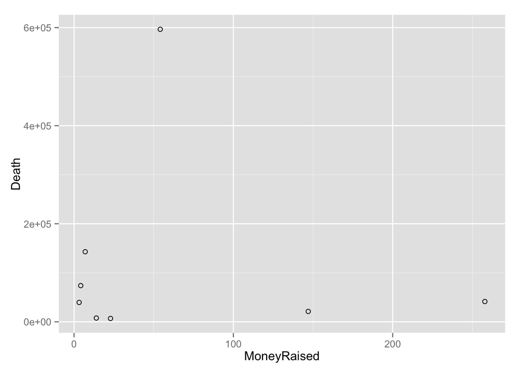

```r
?ggplot #Get R on-line help

ggplot(demo, aes(x=MoneyRaised, y=Death)) +
    geom_point(shape=1)
```

2nd try: 1) change the scale of y-axis Death, because people in general don’t like “4e+05” 2) give informative main, x-axis, y-axis labels

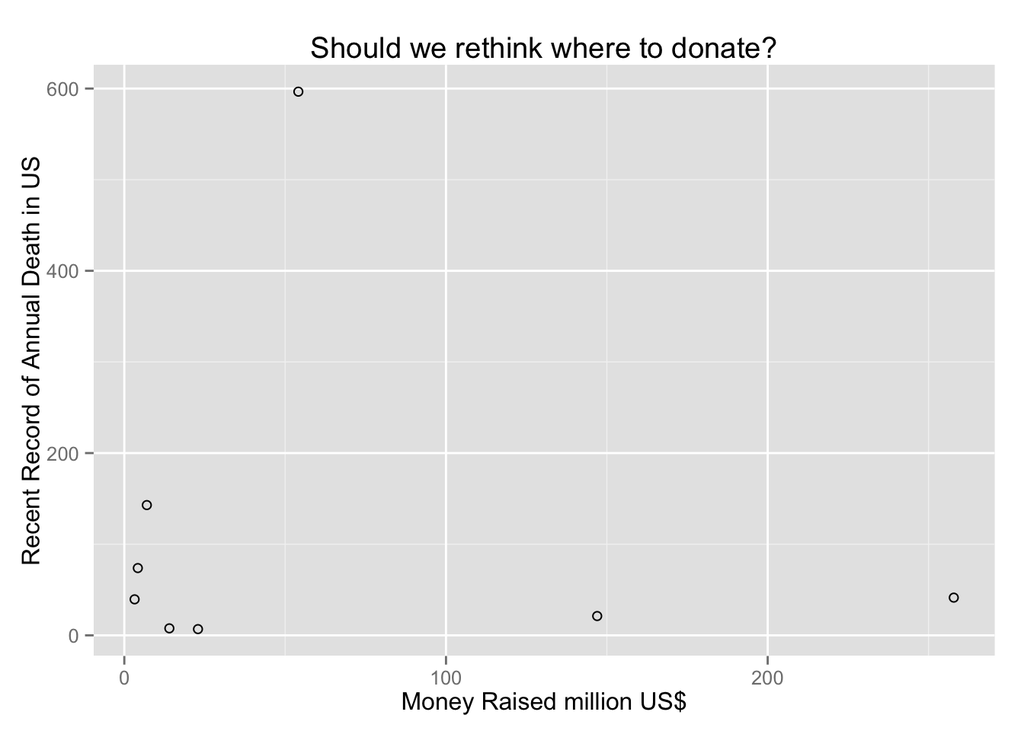

```r
demo$Death<-as.numeric(demo$Death)
demo$Death<-demo$Death/1000
ggplot(demo, aes(x=MoneyRaised, y=Death)) +
    geom_point(shape=1) +xlab("Money Raised million US$") +
    ylab("Recent Record of Annual Death in US") +
    ggtitle("Should we rethink where to donate?")
```

3rd try: Label the dots, make it clear for the readers

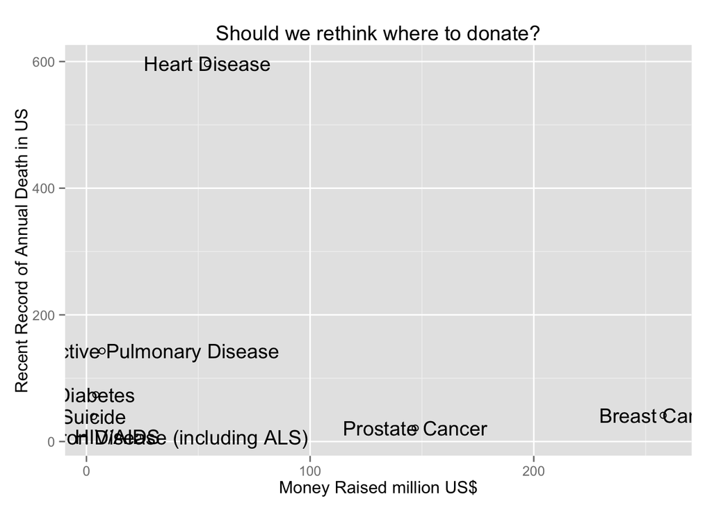

```r
ggplot(demo, aes(x=MoneyRaised, y=Death,label=Name)) +
    geom_point(shape=1) +
    xlab("Money Raised million US$") +
    ylab("Recent Record of Annual Death in US") +
    ggtitle("Should we rethink where to donate?")+
    geom_text(aes(label=Name))
```

Final: Adjust the point label

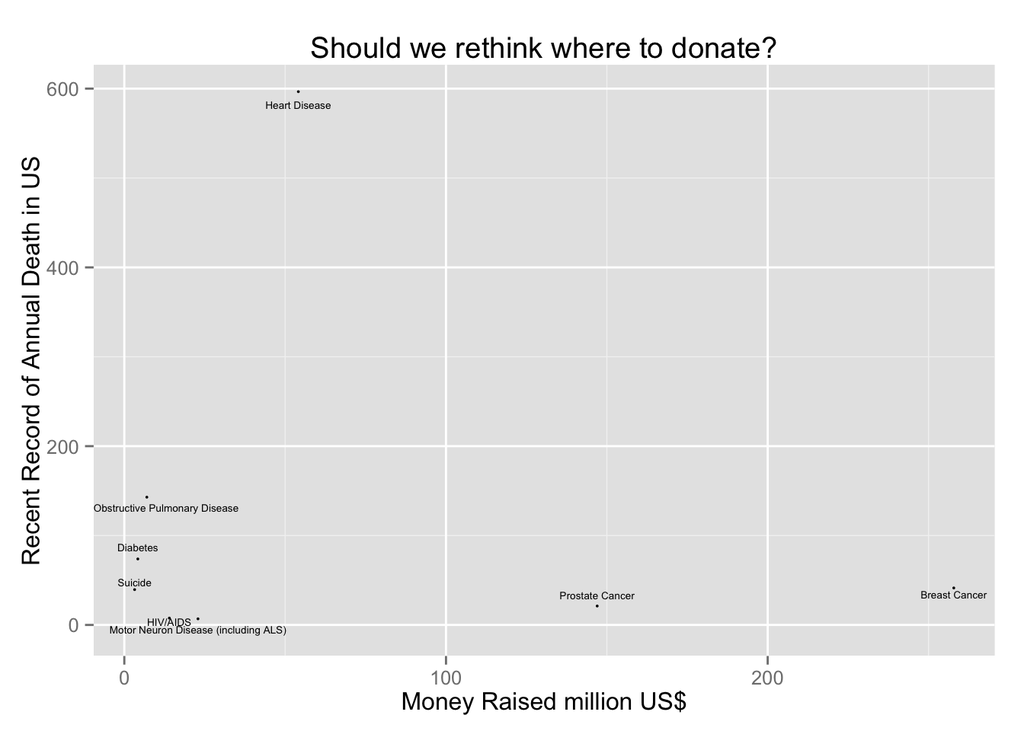

```r
ggplot(demo, aes(x=MoneyRaised, y=Death,label=Name)) +
    geom_point(shape=1,size=0.3) +
    geom_text(aes(label=Name),size=1.8,position=position_jitter(width=-8, height=21))+
    xlab("Money Raised million US$") +
    ylab("Recent Record of Annual Death in US") +
    ggtitle("Should we rethink where to donate?")
```

## Wrap-up:

- Always remember to check working directory getwd or set the right working directory setwd
- Use on-line help, get used to read tutorials on CRAN; also Google and Stack Overflow
- Define meaningful&easy names for datasets and variables, remember R is case sensitive
- Practice and create your own cheatsheet
- Quiz: To read dataset from other statistical analysis software, like Stata and SPSS, what packages shall we use?

## Useful Resources:

- [R basic](http://cran.r-project.org/manuals.html)
- [R for Beginners](http://cran.r-project.org/doc/contrib/Paradis-rdebuts_en.pdf)
- [R in a Nutshell](http://web.udl.es/Biomath/Bioestadistica/R/Manuals/r_in_a_nutshell.pdf)
- [Quick R](http://www.statmethods.net)
- [Data Analysis Examples with R](http://www.ats.ucla.edu/stat/dae/)
- [Rseek](http://www.rseek.org/) * I just heard about this cool website from this morning *